# Lathyrus ms2: Calculation number of years FFD, flowering, fitness, flowering with fitness

Read definitive data file for the old period

|  | year | id_nr | id | fcode | FFD | n_fl | n_fr | totseed | intactseed | shoot_vol | period |
| --- | --- | --- | --- | --- | --- | --- | --- | --- | --- | --- | --- |
| 1 | 1989 | 1 | old_1 | 1 | NA | 6 | 3 | 8 | 6 | 1418.6000 | old |
| 2 | 1990 | 1 | old_1 | 0 | NA | 0 | 0 | 0 | 0 | 523.2000 | old |
| 3 | 1991 | 1 | old_1 | 1 | 59.91181 | 23 | 3 | 12 | 12 | 1915.4000 | old |
| 4 | 1992 | 1 | old_1 | 1 | 55.66944 | 19 | 2 | 6 | 1 | 1460.1917 | old |
| 5 | 1993 | 1 | old_1 | 1 | NA | NA | 0 | 0 | 0 | 879.6493 | old |
| 6 | 1994 | 1 | old_1 | 1 | 59.18403 | 14 | 1 | 3 | 3 | 1338.6727 | old |

Extract data for the new period from data used for ms1

|  | year | period | id | FFD | n_fl | shoot_vol | n_fr | totseed | intactseed | id_nr |
| --- | --- | --- | --- | --- | --- | --- | --- | --- | --- | --- |
| 1 | 2006 | new | new_1 | 60.00286 | 12.34242 | 1830.44 | 0 | 0 | 0.0000 | 1 |
| 2 | 2006 | new | new_2 | 56.27431 | 2.00000 | 1337.34 | 0 | 0 | 0.0000 | 2 |
| 3 | 2006 | new | new_3 | 56.27431 | 8.00000 | 2714.66 | 1 | 2 | 0.0000 | 3 |
| 4 | 2006 | new | new_4 | NA | NA | NA | NA | NA | NA | 4 |
| 5 | 2006 | new | new_5 | 55.27431 | 39.00000 | 5700.87 | 5 | 31 | 21.3125 | 5 |
| 6 | 2006 | new | new_6 | 53.27431 | 76.00000 | 10225.17 | 17 | 61 | 36.0000 | 6 |

Read info about number of shoots and shoot volume (to see when plants were not flowering but were vegetative)

|  | year | info_nshoots_vol | id_nr |
| --- | --- | --- | --- |
| 1 | 2006 | 1 | 1 |
| 2 | 2007 | 0 | 1 |
| 3 | 2008 | 0 | 1 |
| 4 | 2009 | 0 | 1 |
| 5 | 2010 | 0 | 1 |
| 6 | 2011 | 0 | 1 |

|  | year | id_nr | id | fcode | FFD | n_fl | n_fr | totseed | intactseed | shoot_vol | period |
| --- | --- | --- | --- | --- | --- | --- | --- | --- | --- | --- | --- |
| 1 | 2006 | 1 | new_1 | 1 | 60.00286 | 12.34242 | 0 | 0 | 0 | 1830.44 | new |
| 2 | 2007 | 1 | new_1 | NA | NA | NA | NA | NA | NA | NA | new |
| 3 | 2008 | 1 | new_1 | NA | NA | NA | NA | NA | NA | NA | new |
| 4 | 2009 | 1 | new_1 | NA | NA | NA | NA | NA | NA | NA | new |
| 5 | 2010 | 1 | new_1 | NA | NA | NA | NA | NA | NA | NA | new |
| 6 | 2011 | 1 | new_1 | NA | NA | NA | NA | NA | NA | NA | new |

Merge the definitive datasets for old and new period

|  | year | id_nr | id | fcode | FFD | n_fl | n_fr | totseed | intactseed | shoot_vol | period |
| --- | --- | --- | --- | --- | --- | --- | --- | --- | --- | --- | --- |
| 1 | 1989 | 1 | old_1 | 1 | NA | 6 | 3 | 8 | 6 | 1418.6000 | old |
| 2 | 1990 | 1 | old_1 | 0 | NA | 0 | 0 | 0 | 0 | 523.2000 | old |
| 3 | 1991 | 1 | old_1 | 1 | 59.91181 | 23 | 3 | 12 | 12 | 1915.4000 | old |
| 4 | 1992 | 1 | old_1 | 1 | 55.66944 | 19 | 2 | 6 | 1 | 1460.1917 | old |
| 5 | 1993 | 1 | old_1 | 1 | NA | NA | 0 | 0 | 0 | 879.6493 | old |
| 6 | 1994 | 1 | old_1 | 1 | 59.18403 | 14 | 1 | 3 | 3 | 1338.6727 | old |

In the table below, for each year, 1 means that there is a value of the variable for that year, and 0 means that there is no value (NA).

| id | id_nr | period | variable | y1987 | y1988 | y1989 | y1990 | y1991 | y1992 | y1993 | y1994 | y1995 | y1996 | y2006 | y2007 | y2008 | y2009 | y2010 | y2011 | y2012 | y2013 | y2014 | y2015 | y2016 | y2017 |
| --- | --- | --- | --- | --- | --- | --- | --- | --- | --- | --- | --- | --- | --- | --- | --- | --- | --- | --- | --- | --- | --- | --- | --- | --- | --- |
| old_1 | 1 | old | fcode | 0 | 0 | 1 | 1 | 1 | 1 | 1 | 1 | 1 | 0 | 0 | 0 | 0 | 0 | 0 | 0 | 0 | 0 | 0 | 0 | 0 | 0 |
| old_1 | 1 | old | FFD | 0 | 0 | 0 | 0 | 1 | 1 | 0 | 1 | 0 | 0 | 0 | 0 | 0 | 0 | 0 | 0 | 0 | 0 | 0 | 0 | 0 | 0 |
| old_1 | 1 | old | n_fl | 0 | 0 | 1 | 1 | 1 | 1 | 0 | 1 | 1 | 0 | 0 | 0 | 0 | 0 | 0 | 0 | 0 | 0 | 0 | 0 | 0 | 0 |
| old_1 | 1 | old | n_fr | 0 | 0 | 1 | 1 | 1 | 1 | 1 | 1 | 1 | 0 | 0 | 0 | 0 | 0 | 0 | 0 | 0 | 0 | 0 | 0 | 0 | 0 |
| old_1 | 1 | old | totseed | 0 | 0 | 1 | 1 | 1 | 1 | 1 | 1 | 1 | 0 | 0 | 0 | 0 | 0 | 0 | 0 | 0 | 0 | 0 | 0 | 0 | 0 |
| old_1 | 1 | old | intactseed | 0 | 0 | 1 | 1 | 1 | 1 | 1 | 1 | 1 | 0 | 0 | 0 | 0 | 0 | 0 | 0 | 0 | 0 | 0 | 0 | 0 | 0 |
| old_1 | 1 | old | shoot_vol | 0 | 1 | 1 | 1 | 1 | 1 | 1 | 1 | 1 | 0 | 0 | 0 | 0 | 0 | 0 | 0 | 0 | 0 | 0 | 0 | 0 | 0 |
| old_2 | 2 | old | fcode | 0 | 0 | 0 | 0 | 0 | 1 | 1 | 1 | 1 | 0 | 0 | 0 | 0 | 0 | 0 | 0 | 0 | 0 | 0 | 0 | 0 | 0 |
| old_2 | 2 | old | FFD | 0 | 0 | 0 | 0 | 0 | 1 | 1 | 1 | 1 | 0 | 0 | 0 | 0 | 0 | 0 | 0 | 0 | 0 | 0 | 0 | 0 | 0 |
| old_2 | 2 | old | n_fl | 0 | 0 | 0 | 0 | 0 | 1 | 1 | 1 | 1 | 0 | 0 | 0 | 0 | 0 | 0 | 0 | 0 | 0 | 0 | 0 | 0 | 0 |

[output cut: 990 more lines]

In the table below, 1 means that the plant was flowering, 0 that it was not flowering (vegetative), and NA that no data is available for that year

| id | 1987 | 1988 | 1989 | 1990 | 1991 | 1992 | 1993 | 1994 | 1995 | 1996 | 2006 | 2007 | 2008 | 2009 | 2010 | 2011 | 2012 | 2013 | 2014 | 2015 | 2016 | 2017 |
| --- | --- | --- | --- | --- | --- | --- | --- | --- | --- | --- | --- | --- | --- | --- | --- | --- | --- | --- | --- | --- | --- | --- |
| old_1 | NA | NA | 1 | 0 | 1 | 1 | 1 | 1 | 0 | NA | NA | NA | NA | NA | NA | NA | NA | NA | NA | NA | NA | NA |
| old_2 | NA | NA | NA | NA | NA | 1 | 1 | 1 | 1 | NA | NA | NA | NA | NA | NA | NA | NA | NA | NA | NA | NA | NA |
| old_3 | 1 | 1 | 0 | 1 | 1 | 1 | 1 | 0 | 1 | NA | NA | NA | NA | NA | NA | NA | NA | NA | NA | NA | NA | NA |
| old_4 | 1 | 0 | 1 | 1 | 1 | 1 | 1 | 0 | 1 | 1 | NA | NA | NA | NA | NA | NA | NA | NA | NA | NA | NA | NA |
| old_5 | 1 | 0 | 0 | NA | 0 | 0 | 0 | NA | 0 | NA | NA | NA | NA | NA | NA | NA | NA | NA | NA | NA | NA | NA |
| old_6 | 1 | 1 | 1 | 1 | 1 | 1 | 1 | 1 | 0 | NA | NA | NA | NA | NA | NA | NA | NA | NA | NA | NA | NA | NA |
| old_7 | NA | 1 | 1 | 1 | 1 | 1 | 1 | 1 | 1 | NA | NA | NA | NA | NA | NA | NA | NA | NA | NA | NA | NA | NA |
| old_8 | 1 | 1 | NA | 0 | 1 | 1 | 1 | 0 | NA | 1 | NA | NA | NA | NA | NA | NA | NA | NA | NA | NA | NA | NA |
| old_9 | NA | 0 | 0 | 0 | NA | NA | 0 | NA | 0 | NA | NA | NA | NA | NA | NA | NA | NA | NA | NA | NA | NA | NA |
| old_10 | NA | 0 | NA | 0 | 0 | NA | 0 | NA | 0 | NA | NA | NA | NA | NA | NA | NA | NA | NA | NA | NA | NA | NA |

[output cut: 990 more lines]

Calculate number of years with information on FFD (n_years_FFD), number of years of flowering (n_years_flowering), number of years with information on fitness, and number of flowering years with information on fitness for each plant

| id | id_nr | period | n_years_FFD | n_years_flowering | n_years_fitness | n_years_fl_fitness |
| --- | --- | --- | --- | --- | --- | --- |
| old_1 | 1 | old | 3 | 5 | 7 | 5 |
| old_2 | 2 | old | 4 | 4 | 4 | 4 |
| old_3 | 3 | old | 6 | 7 | 9 | 7 |
| old_4 | 4 | old | 7 | 8 | 10 | 8 |
| old_5 | 5 | old | 1 | 1 | 7 | 1 |
| old_6 | 6 | old | 8 | 8 | 9 | 8 |

Remove ids with n_years_FFD==0

Read data on duration of the study:

|  | id_nr | period | id | n_years_study |
| --- | --- | --- | --- | --- |
| 1 | 1 | old | old_1 | 8 |
| 2 | 2 | old | old_2 | 4 |
| 3 | 3 | old | old_3 | 9 |
| 4 | 4 | old | old_4 | 10 |
| 5 | 5 | old | old_5 | 9 |
| 6 | 6 | old | old_6 | 9 |

Add info on duration of the study (n_years_study) to n_years_def:

| id | id_nr | period | n_years_FFD | n_years_flowering | n_years_fitness | n_years_fl_fitness | n_years_study |
| --- | --- | --- | --- | --- | --- | --- | --- |
| old_1 | 1 | old | 3 | 5 | 7 | 5 | 8 |
| old_2 | 2 | old | 4 | 4 | 4 | 4 | 4 |
| old_3 | 3 | old | 6 | 7 | 9 | 7 | 9 |
| old_4 | 4 | old | 7 | 8 | 10 | 8 | 10 |
| old_5 | 5 | old | 1 | 1 | 7 | 1 | 9 |
| old_6 | 6 | old | 8 | 8 | 9 | 8 | 9 |

Some plots:

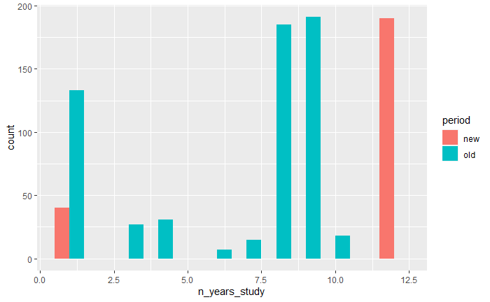

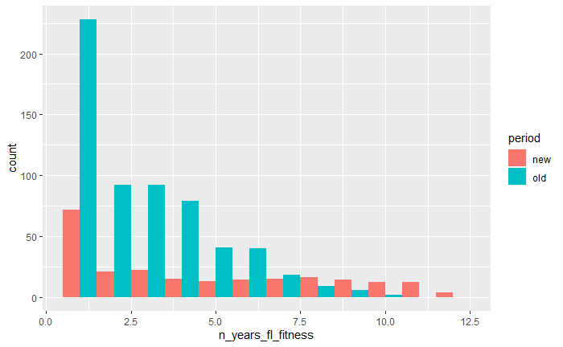

Add info on n_years_fl_fitness and n_years_study to datadef

|  | year | id_nr | id | fcode | FFD | n_fl | n_fr | totseed | intactseed | shoot_vol | period | n_years_fl_fitness | n_years_study |
| --- | --- | --- | --- | --- | --- | --- | --- | --- | --- | --- | --- | --- | --- |
| 1 | 1989 | 1 | old_1 | 1 | NA | 6 | 3 | 8 | 6 | 1418.6000 | old | 5 | 8 |
| 2 | 1990 | 1 | old_1 | 0 | NA | 0 | 0 | 0 | 0 | 523.2000 | old | 5 | 8 |
| 3 | 1991 | 1 | old_1 | 1 | 59.91181 | 23 | 3 | 12 | 12 | 1915.4000 | old | 5 | 8 |
| 4 | 1992 | 1 | old_1 | 1 | 55.66944 | 19 | 2 | 6 | 1 | 1460.1917 | old | 5 | 8 |
| 5 | 1993 | 1 | old_1 | 1 | NA | NA | 0 | 0 | 0 | 879.6493 | old | 5 | 8 |
| 6 | 1994 | 1 | old_1 | 1 | 59.18403 | 14 | 1 | 3 | 3 | 1338.6727 | old | 5 | 8 |

Add temperature data (mean April temp) to datadef

|  | year | id_nr | id | fcode | FFD | n_fl | n_fr | totseed | intactseed | shoot_vol | period | n_years_fl_fitness | n_years_study | mean_4 | cmean_4 |
| --- | --- | --- | --- | --- | --- | --- | --- | --- | --- | --- | --- | --- | --- | --- | --- |
| 1 | 1989 | 1 | old_1 | 1 | NA | 6 | 3 | 8 | 6 | 1418.6000 | old | 5 | 8 | 5.236667 | -0.228207783 |
| 2 | 1990 | 1 | old_1 | 0 | NA | 0 | 0 | 0 | 0 | 523.2000 | old | 5 | 8 | 7.195000 | 1.730125551 |
| 3 | 1991 | 1 | old_1 | 1 | 59.91181 | 23 | 3 | 12 | 12 | 1915.4000 | old | 5 | 8 | 5.245000 | -0.219874449 |
| 4 | 1992 | 1 | old_1 | 1 | 55.66944 | 19 | 2 | 6 | 1 | 1460.1917 | old | 5 | 8 | 3.828333 | -1.636541116 |
| 5 | 1993 | 1 | old_1 | 1 | NA | NA | 0 | 0 | 0 | 879.6493 | old | 5 | 8 | 5.461667 | -0.003207783 |
| 6 | 1994 | 1 | old_1 | 1 | 59.18403 | 14 | 1 | 3 | 3 | 1338.6727 | old | 5 | 8 | 6.418333 | 0.953458884 |

datadef is ready for analyses!